# Assignment 6

Import the "pandas" and "matplotlib.pyplot" libraries (and any other libraries if you would like)

```python
# Import libraries
import pandas as pd
import matplotlib.pyplot as plt
```

(a) Functions

- Read in the dataset named "features.csv".
- Create a `lambda` function that checks if weight $≤$ 3000
- Using the Pandas method `.apply()`, create a new Series that shows `True` if weight $≤$ 3000 and `False`if weight > 3000.
- Using the `.shape` attribute, print the number of cars that have weight $≤$ 3000.
- Using Python commands, print the number of cars that have weight $\leq$ 3000.

**Note**: When I say "Using Python commands" that means you **should not** do either of the following:

```
print(230)
```

```
some_variable_name = 230
```

(Yes, you should get the number 230 if you did everything correctly)

```python
# Write your answer here:

features = pd.read_csv("data/features.csv")

weight_checker = lambda x: x <= 3000

features["weight"] = features["weight"].apply(weight_checker)
print(features["weight"].sum())
```

```
230
```

(b) Subsetting Data

- Read in the dataset named "features.csv".
- Define a global variable called `threshold` that takes the  
  value 2500
- Subset the data to get one dataset with weight $>$ threshold and  
  another with weight $\le$ threshold. Use the `.query()` function.
- Compute the mean acceleration for each of these datasets, printing these values to the screen

Note: Review how to define a global variable inside `.query()`

```python
# Write your answer here:
features = pd.read_csv("data/features.csv")

threshold = 2500

Heavy_cars = features.query("weight > @threshold")
Skinny_cars = features.query("weight <= @threshold")

print(Heavy_cars["acceleration"].mean())
print(Skinny_cars["acceleration"].mean())
```

```
14.999601593625497
16.53877551020408
```

(c) Use sorting + ".iloc[]"

- Read the "fifa23_players_basic.csv" dataset
- Use ".sort_values()" to order the "Age" column  
  from oldest to youngest
- Get a subset with the 5 oldest players

```python
# Write your answer here:
fifa23_players_basic = pd.read_csv("data/fifa23_players_basic.csv")

fifa23_players_basic

fifa23_sorted_by_age = fifa23_players_basic.sort_values(by = "Age", ascending= False)

fifa23_sorted_by_age = fifa23_sorted_by_age.iloc[ :5, ]

fifa23_sorted_by_age
```

|  | Known As | Full Name | Overall | Potential | Value(in Euro) | Positions Played | Best Position | Nationality | Image Link | Age | ... | Preferred Foot | Weak Foot Rating | Skill Moves | International Reputation | National Team Name | National Team Image Link | National Team Position | National Team Jersey Number | Attacking Work Rate | Defensive Work Rate |
| --- | --- | --- | --- | --- | --- | --- | --- | --- | --- | --- | --- | --- | --- | --- | --- | --- | --- | --- | --- | --- | --- |
| 592 | G. Buffon | Gianluigi Buffon | 79 | 79 | 1900000 | GK | GK | Italy | https://cdn.sofifa.net/players/001/179/23_60.png | 44 | ... | Right | 2 | 1 | 4 | - | https://cdn.sofifa.net/flags/it.png | - | - | Medium | Medium |
| 13548 | S. Lukić | Stojan Lukić | 62 | 62 | 45000 | GK | GK | Bosnia and Herzegovina | https://cdn.sofifa.net/players/213/483/23_60.png | 42 | ... | Right | 2 | 1 | 1 | - | - | - | - | Medium | Medium |
| 3276 | S. Torrico | Sebastián Torrico | 72 | 72 | 250000 | GK | GK | Argentina | https://cdn.sofifa.net/players/216/692/23_60.png | 42 | ... | Right | 2 | 1 | 1 | - | https://cdn.sofifa.net/flags/ar.png | - | - | Medium | Medium |
| 15525 | J. Szmatuła | Jakub Szmatuła | 59 | 59 | 25000 | GK | GK | Poland | https://cdn.sofifa.net/players/155/422/23_60.png | 41 | ... | Right | 3 | 1 | 1 | - | https://cdn.sofifa.net/flags/pl.png | - | - | Medium | Medium |
| 10851 | M. Galezo | Moisés Galezo | 64 | 64 | 0 | CB | CB | Venezuela | https://cdn.sofifa.net/players/265/721/23_60.png | 41 | ... | Right | 3 | 2 | 1 | - | https://cdn.sofifa.net/flags/ve.png | - | - | Medium | High |

5 rows × 32 columns

(d) Use queries + global variables

- Read the "fifa23_players_basic.csv" dataset
- Compute the mean of the column "Weight(in kg)" and store it as a variable
- Subset the players whose Weight in kilograms is stricly large than this mean value using ".query()"

HINT: Remember that there is a special syntax for when using column names inside the .query() method (the backtick `)

```python
# Write your answer here:
fifa23_players_basic = pd.read_csv("data/fifa23_players_basic.csv")
fifa23_players_basic

Mean_Weight_of_Players = fifa23_players_basic["Weight(in kg)"].mean()

fifa23_heavy_players = fifa23_players_basic.query ("`Weight(in kg)` > @Mean_Weight_of_Players")

print(fifa_23_heavy_players)
```

[output not shown]

[output cut: 77 more lines]

(e) Plot by Category

Read in the dataset named "wdi_urban.csv".

This contains data from 1980 and 2020.

- **Create an array with the unique values of "year" using the `Pandas` function `unique`**
- **Create a plot with a ...**
  - Histogram of "prop_urbanpopulation" (proportion of urban population) for each year
  - Set the histogram option `alpha = 0.5` for transparency
  - All the histograms should be overlapping on the same plot
  - Create a legend with the list of years
  - Label the axes and the title

**Hint**: The procedure will be similar (but not exactly the same!) as when we created a scatter plot of cars with different numbers of cylinders in Lecture 11

```python
wdi_urban = pd.read_csv("data/wdi_urban.csv")
wdi_urban
```

|  | year | yearcode | countryname | countrycode | prop_urbanpopulation |
| --- | --- | --- | --- | --- | --- |
| 0 | 1980 | YR1980 | Afghanistan | AFG | 15.995 |
| 1 | 1980 | YR1980 | Albania | ALB | 33.762 |
| 2 | 1980 | YR1980 | Algeria | DZA | 43.542 |
| 3 | 1980 | YR1980 | American Samoa | ASM | 74.330 |
| 4 | 1980 | YR1980 | Andorra | AND | 92.064 |
| ... | ... | ... | ... | ... | ... |
| 429 | 2020 | YR2020 | Virgin Islands (U.S.) | VIR | 95.939 |
| 430 | 2020 | YR2020 | West Bank and Gaza | PSE | 76.719 |
| 431 | 2020 | YR2020 | Yemen, Rep. | YEM | 37.908 |
| 432 | 2020 | YR2020 | Zambia | ZMB | 44.629 |
| 433 | 2020 | YR2020 | Zimbabwe | ZWE | 32.242 |

434 rows × 5 columns

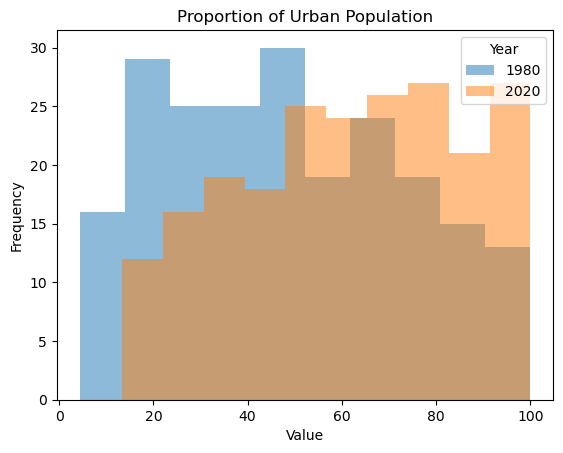

```python
# your answer here
wdi_urban = pd.read_csv("data/wdi_urban.csv")

years = wdi_urban["year"].unique()

for value in years:
    subset = wdi_urban.query("year == @value")
    plt.hist( subset["prop_urbanpopulation"], alpha = 0.5)

plt.title("Proportion of Urban Population")
plt.xlabel("Value")
plt.ylabel("Frequency")
plt.legend(title = "Year", labels = years)
plt.show()
```